# Kenya’s Job Market

Florence Muriuki

6/30/2019

There were 37034 jobs posted between 2016-09-07 and 2019-06-14 on [jobmag Kenya](https://www.myjobmag.co.ke/). According to the chart below, 2019 has witnessed decrease in jobs posted.

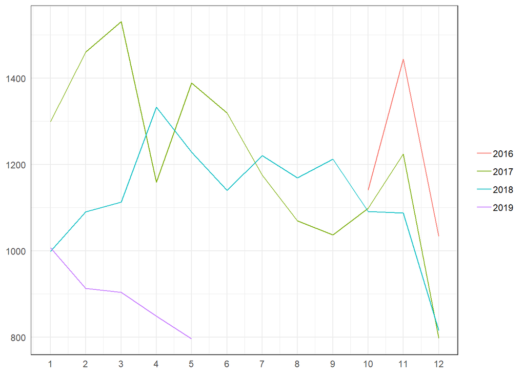

Unsurprisingly, most of the top posters were recruitment agencies. Here are the recruitment and non-recruitment firms with highest number of posts:

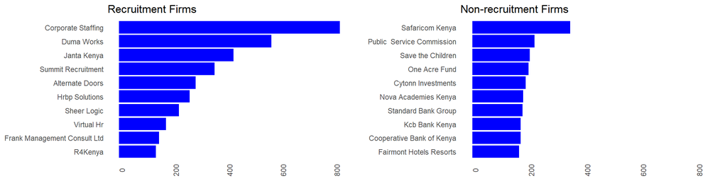

In terms of number of jobs postef, Safaricom led the pack of non-recruitment organizations followed by Public Service Commission and Save the Children.A quick look at Safaricom posts shows that ICT/Engineering, Sales & Marketing, Administration, Finance/Accounting and Customer Care formed the bulk of its job posts.

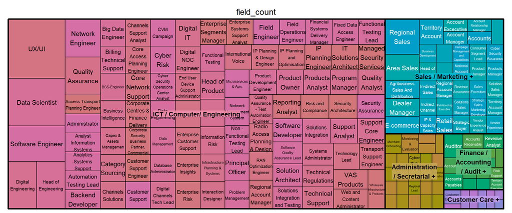

When the job posts are classified according to the industry of the poster/employer, NGOs and the Government emerge as the top posters. Recruitment firms contribute to the Consulting Industry high rank.

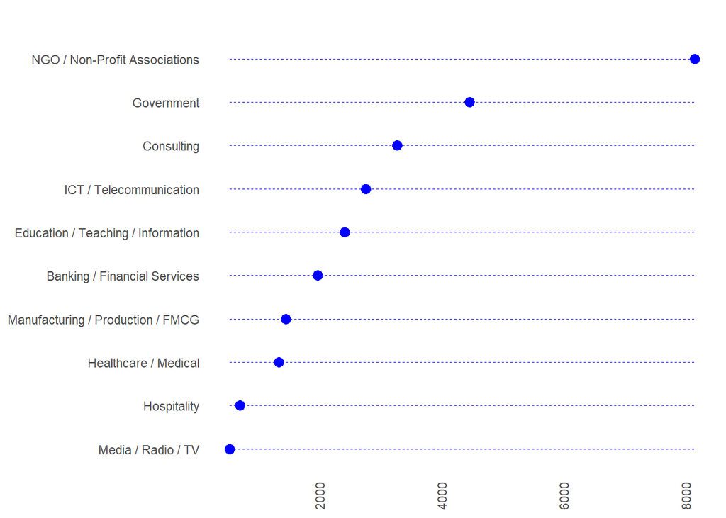

The NGOs that posted a significant number of jobs include:

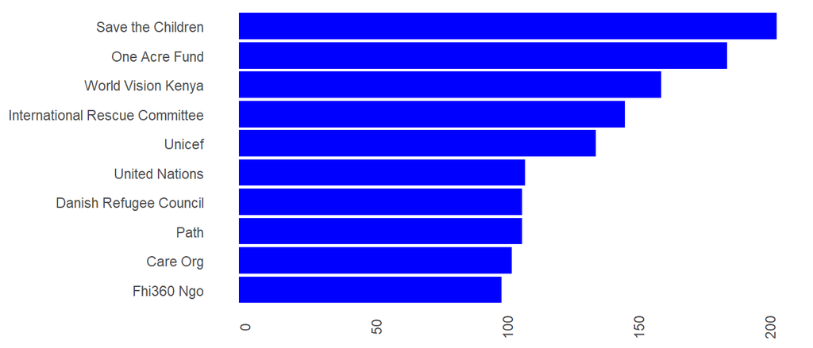

2718 jobs were posted by the Central Government and parastatals while 1610 jobs were posted by county governments.

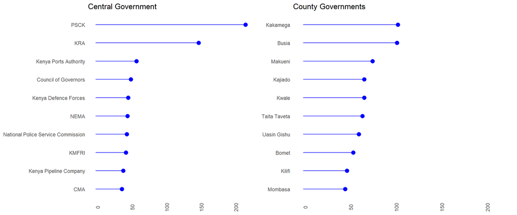

The top 10 job fields are:

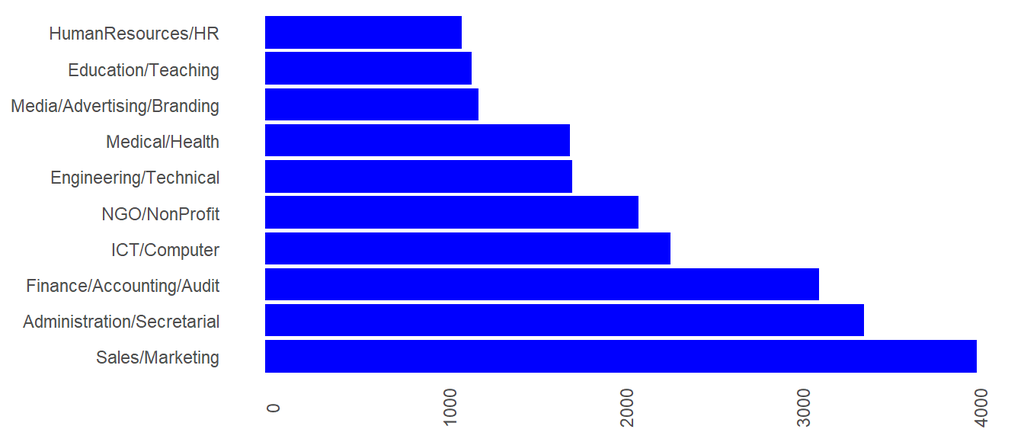

I was curious about data related jobs. I Used the following keywords to filter job titles related data functions: data, machine learning, deep learning, artificial intelligence and statistic. Data analyst was the most common job title in this category. Data analyst is the most common job title.

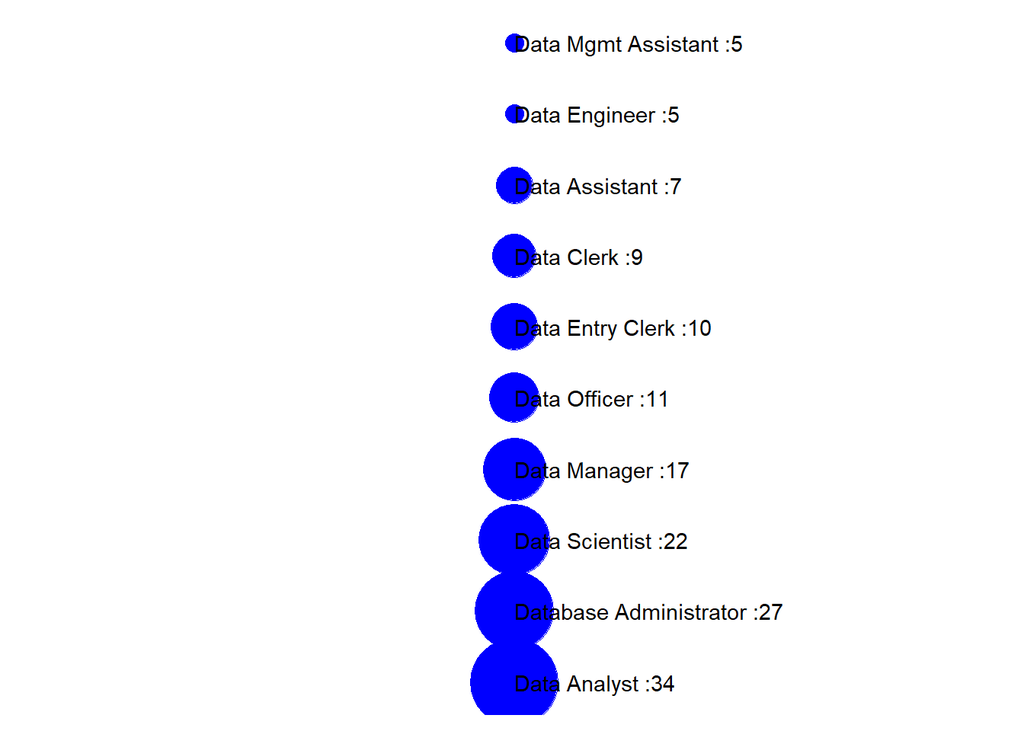